# Machine Learning Project with ROCKET

## Objective

The objective of this assignment is to identify good models for classifying time series data.  
The data is from an accelerometer sensor and there are samples of fatigued and non-fatigued running. The data has been segmented into strides and the segments (samples) are labelled F (fatigued) and NF (not fatigued). The data for two subjects A and B are available in the files `fatigueA.csv` and `fatigueB.csv`. This dataset is extracted from a much larger dataset described [here](https://openreview.net/pdf?id=9c0lAonDNP).  
At present, the best performing method for time-series classification is [Rocket](https://openreview.net/pdf?id=9c0lAonDNP). A rocket implementation is available in the [sktime tool kit](https://www.sktime.net/en/latest/api_reference/auto_generated/sktime.transformations.panel.rocket.Rocket.html). This sktime implementation can be used in this assignment.  
Some code to get you started in available in the notebook `RunningCore`.

```python
# pip install sktime
```

```python
import pandas as pd
import numpy as np
import matplotlib.pyplot as plt
from sklearn.model_selection import GridSearchCV, TimeSeriesSplit
```

```python
fatigue_df = pd.read_csv('fatigueA.csv', header = None) # sep = '\s+')
print(fatigue_df.shape)
fatigue_df.head(5)
```

```
(421, 181)
```

|  | 0 | 1 | 2 | 3 | 4 | 5 | 6 | 7 | 8 | 9 | ... | 171 | 172 | 173 | 174 | 175 | 176 | 177 | 178 | 179 | 180 |
| --- | --- | --- | --- | --- | --- | --- | --- | --- | --- | --- | --- | --- | --- | --- | --- | --- | --- | --- | --- | --- | --- |
| 0 | F | 2.72 | 2.69 | 2.75 | 2.89 | 3.07 | 3.27 | 3.48 | 3.67 | 3.82 | ... | 6.50 | 6.16 | 5.75 | 5.29 | 4.79 | 4.29 | 3.83 | 3.42 | 3.09 | 2.85 |
| 1 | F | 2.68 | 2.47 | 2.46 | 2.54 | 2.69 | 2.93 | 3.36 | 3.99 | 4.75 | ... | 2.79 | 3.88 | 5.18 | 6.29 | 6.88 | 6.80 | 6.13 | 5.11 | 4.04 | 3.20 |
| 2 | F | 5.04 | 5.69 | 6.21 | 6.52 | 6.59 | 6.47 | 6.26 | 6.06 | 5.91 | ... | 5.89 | 5.29 | 4.72 | 4.20 | 3.77 | 3.47 | 3.36 | 3.47 | 3.82 | 4.38 |
| 3 | F | 2.42 | 3.21 | 4.02 | 4.58 | 4.77 | 4.64 | 4.39 | 4.25 | 4.42 | ... | 8.60 | 8.76 | 8.76 | 8.32 | 7.34 | 5.91 | 4.33 | 2.97 | 2.14 | 1.98 |
| 4 | F | 3.35 | 3.40 | 3.89 | 4.71 | 5.66 | 6.47 | 6.90 | 6.81 | 6.25 | ... | 9.45 | 8.52 | 7.75 | 7.14 | 6.63 | 6.15 | 5.60 | 4.96 | 4.28 | 3.69 |

5 rows × 181 columns

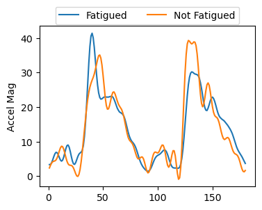

```python
fatigue_df.iloc[4][1:].plot(label='Fatigued')
fatigue_df.iloc[-5][1:].plot(figsize=(4,3), label = 'Not Fatigued')
plt.legend(loc='upper center', bbox_to_anchor=(0.5, 1.15),ncol=2)
plt.ylabel('Accel Mag')
```

```python
y = fatigue_df.pop(0).values
X = fatigue_df.values
```

## Task 1

Calculate the accuracy of a logistic regression classifier (`SGDClassifier`) on the raw time series data for subject A.

### 1.1 Training dataset by Logistic Regression model and Access the accuracy for baseline logistic regression classifier

```python
X.shape, y.shape
```

```
((421, 180), (421,))
```

```python
from sklearn.model_selection import train_test_split
from sklearn.linear_model import SGDClassifier
from sklearn.metrics import accuracy_score
from sklearn.model_selection import train_test_split
from sklearn.linear_model import SGDClassifier
from sklearn.metrics import accuracy_score, precision_score, recall_score, confusion_matrix, f1_score
```

```python
# Splitting data into training and testing sets
X_train, X_test, y_train, y_test = train_test_split(X, y, test_size=0.2, random_state=10)
```

```python
# from sklearn.preprocessing import StandardScaler

# # Initialize the StandardScaler
# scaler = StandardScaler()

# # Fit the scaler on the training data and transform both training and test data
# X_train_scaled = scaler.fit_transform(X_train)
# X_test_scaled = scaler.transform(X_test)
```

```python
from sklearn.preprocessing import StandardScaler
from sklearn.pipeline import make_pipeline
from sklearn.model_selection import cross_val_score

# Creating a logistic regression model with SGD
log_sgd = make_pipeline(StandardScaler(), SGDClassifier(loss='log_loss', random_state=10))

# Performing 5-fold cross-validation to evaluate the model
cv_scores = cross_val_score(log_sgd, X, y, cv=5, scoring='accuracy')

# Calculating the average accuracy
average_accuracy_baseline = np.mean(cv_scores)

print(f"Average Accuracy of 5-fold cross-validation: {average_accuracy_baseline:.4f}")
```

```
Average Accuracy of 5-fold cross-validation: 0.7673
```